# Walkthrough of Heterogeneous Treatment Effects Analysis

Thomas Jemielita

Arunava Chakravartty

2026-03-06

# 1 Overview

This document demonstrates the complete workflow for identifying heterogeneous treatment effects, including estimating conditional average treatment effects (CATEs), identifying subgroups, and subgroup-specific treatment estimation. The `benchtm` package (Sophie-Sun/benchtm) is used for simulations. The following models/methods were then applied:

1. **CATE Estimation Methods**:
   - S-Learner (single-model approach via random forest)
   - T-Learner (two-model approach via random forest)
   - X-Learner (Künzel et al., 2019 — cross-arm imputation meta-learner)
   - Causal Forest (`grf` package)
2. **Subgroup Identification Methods**:
   - Virtual Twins (RF-based CATE + regression tree)
   - Model-Based Recursive Partitioning (MOB)
   - `personalized` package (linear regression learner — model-based subgroup rule)

Each method then assigns patients into “Benefitting” (B) (subgroup-level treatment estimate > 0) or “Non-Benefitting” (NB) (treatment estimate ≤ 0) groups, such that the identified subgroups are $S={S_{B}, S_{NB}}$. Here, the goal is to identify which group(s) of patients potentially benefit or do not benefit from the experimental treatment.

3. **Subgroup-Level Treatment Effect Estimation**:
   - Naive (Empirical): Unadjusted difference-in-means within each subgroup: `lm(Y ~ trt)` restricted to each subgroup.
   - Bootstrap (Refit): Uses bootstrap resampling to estimate 95% CIs and/or bias for the subgroup-specific treatment estimates. This involves running the full subgroup identification / estimation process for each bootstrap resample and accounts for variability in both CATE estimation and subgroup identification.
   - Debiased Bootstrap (Guo and He 2021; Zhao, Ivanova, and Fine 2023): Bootstrap based approach with bias-correction that takes into account the selection process. However, this does not require repeating the entire identification process for each bootstrap resample.

## 1.1 Simulation Design

[output not shown]

# 2 Setup and Packages

```r
# Install benchtm if needed:
# devtools::install_github("Sophie-Sun/benchtm")
library(benchtm)
library(ranger)
library(grf)
library(partykit)
library(rpart)
library(rpart.plot)
library(ggplot2)
library(dplyr)
library(tidyr)
library(patchwork)
library(personalized)
library(boot)
library(glmnet)

set.seed(2026)
```

# 3 Data Generation with `benchtm`

We use `benchtm::generate_X_dist()` to create 20 covariates (a mix of binary, exponential, correlated normal, multinomial, and independent normal variables), then `generate_trt()` for 1:1 randomized treatment, and `generate_y()` to create a continuous outcome.

The data-generating model is:

$$Y = f_{\text{prog}}(X) + \text{trt} \cdot \left(\beta_0 + \beta_1 \cdot
f_{\text{pred}}(X)\right) + \varepsilon, \quad \varepsilon \sim N(0,
\sigma)$$

```r
N <- 400
p <- 20

# Generate covariates (benchtm creates X1-X20 with mixed types)
X <- generate_X_dist(n = N, p = p, rho = 0.5)

# 1:1 randomized treatment
trt <- generate_trt(n = N, p_trt = 0.5)

# Define prognostic and predictive expressions
# Prognostic: uses X1 (binary), X2 (exp), X3, X5, X6, X8, X9, X10
prog_expr <- "0.5*X3 + 0.3*X8 + 0.2*X9 + 0.4*X10 + 0.3*X2 + 0.2*(X1=='Y')"

# Predictive: X3, X4, X7 are the true effect modifiers
pred_expr <- "X3 + 0.5*X4 + 0.3*X7"

# Generate outcome
# b0 = 1 (overall treatment effect), b1 = 2 (interaction strength)
dat <- generate_y(
  X = X, trt = trt,
  prog = prog_expr,
  pred = pred_expr,
  b0 = 1, b1 = 2,
  type = "continuous",
  sigma_error = 1.5,
  include_truth = TRUE
)

# Quick summary
out <- c(
  paste("Dimensions:", nrow(dat), "x", ncol(dat)),
  paste("Treatment allocation:", paste(names(table(dat$trt)), table(dat$trt), collapse = ", ")),
  paste("DGP formula:", attr(dat, "form"))
)
cat(paste(out, collapse = "\n"), "\n")
```

```
## Dimensions: 400 x 24
## Treatment allocation: 0 200, 1 200
## DGP formula: mu = 0.5*X3 + 0.3*X8 + 0.2*X9 + 0.4*X10 + 0.3*X2 + 0.2*(X1=='Y') + Trt*(1+2*(X3 + 0.5*X4 + 0.3*X7)) + N(0, 1.5)
```

```r
# Inspect the data and true treatment effects
out <- c(capture.output(print(head(dat[, c("trt", "Y", "trt_effect", "X3", "X4", "X7")]))),
         "",
         "True CATE summary:",
         capture.output(print(summary(dat$trt_effect))))
cat(paste(out, collapse = "\n"), "\n")
```

```
##   trt          Y  trt_effect         X3         X4         X7
## 1   1 -8.2978762 -6.99308851 -3.1076517 -1.4257070 -0.5867969
## 2   0  0.7197838  0.94496676 -0.4893409  0.6410636  0.4709750
## 3   0  0.9282421  4.15284169  0.9215633  1.5148820 -0.3419448
## 4   0  2.3147939 -2.29153362 -0.3571485 -2.1198460 -0.7623177
## 5   1  4.7714466  3.71933187  1.1569001  0.1349683  0.4509391
## 6   0  0.8275862 -0.04938637 -0.1024355 -0.3003517 -0.9069396
##
## True CATE summary:
##    Min. 1st Qu.  Median    Mean 3rd Qu.    Max.
## -6.9931 -0.6834  1.1195  0.9955  2.8488  9.3908
```

## 3.1 Visualize True CATEs

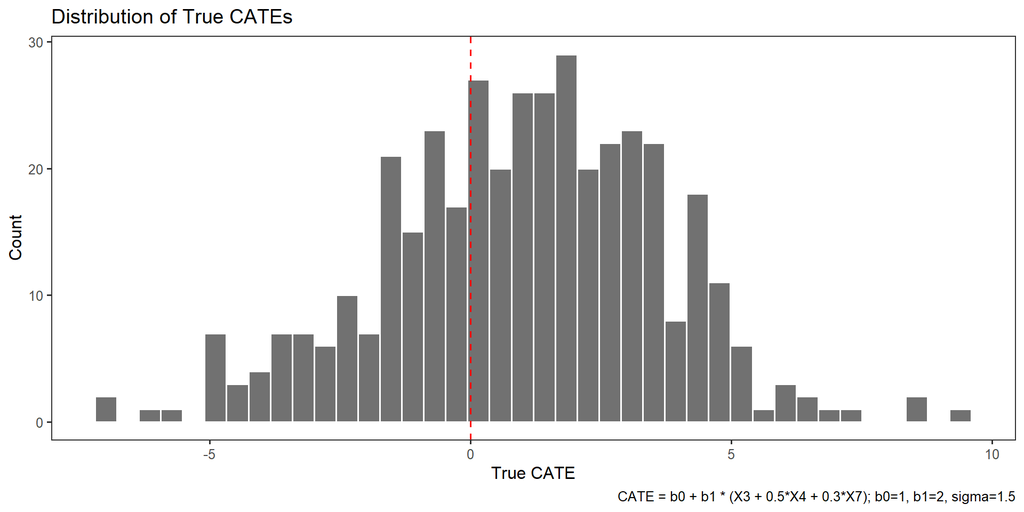

```r
ggplot(dat, aes(x = trt_effect)) +
  geom_histogram(bins = 40, fill = "grey30", color = "white", alpha = 0.8) +
  geom_vline(xintercept = 0, linetype = "dashed", color = "red") +
  labs(
    title = "Distribution of True CATEs",
    x = "True CATE",
    y = "Count",
    caption = "CATE = b0 + b1 * (X3 + 0.5*X4 + 0.3*X7); b0=1, b1=2, sigma=1.5"
  ) +
  theme_bw(base_size = 12) +
  theme(panel.grid = element_blank())
```

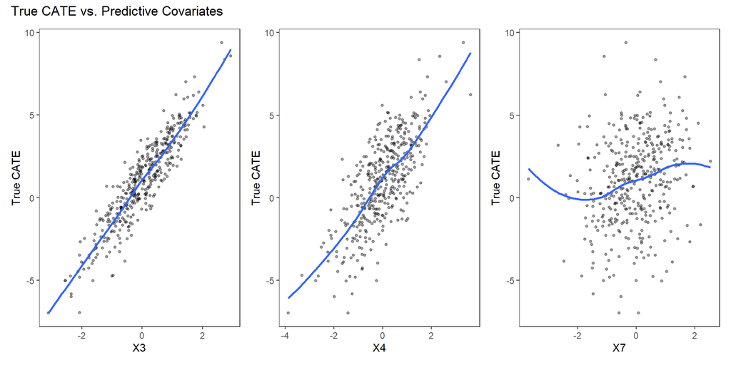

```r
# True CATE vs. the three predictive variables
p1 <- ggplot(dat, aes(x = X3, y = trt_effect)) +
  geom_point(alpha = 0.4, size = 1) + geom_smooth(method = "loess", se = FALSE) +
  labs(y = "True CATE") + theme_bw() + theme(panel.grid = element_blank())
p2 <- ggplot(dat, aes(x = X4, y = trt_effect)) +
  geom_point(alpha = 0.4, size = 1) + geom_smooth(method = "loess", se = FALSE) +
  labs(y = "True CATE") + theme_bw() + theme(panel.grid = element_blank())
p3 <- ggplot(dat, aes(x = X7, y = trt_effect)) +
  geom_point(alpha = 0.4, size = 1) + geom_smooth(method = "loess", se = FALSE) +
  labs(y = "True CATE") + theme_bw() + theme(panel.grid = element_blank())

p1 + p2 + p3 + plot_annotation(title = "True CATE vs. Predictive Covariates")
```

# 4 Prepare Model Data

```r
# Prepare covariate matrix (convert factors to numeric for RF/grf)
X_covs <- dat %>% select(starts_with("X"))
X_covs <- data.frame(X_covs)

# Numeric model matrix for methods that need it (grf, glmnet, personalized)
# model.matrix expands factors to dummy columns
X_mat <- model.matrix(~ . - 1, data = X_covs)

Y <- dat$Y
Trt <- dat$trt          # Note: we use 'Trt' (not 'T') to avoid masking base R's TRUE
true_cate <- dat$trt_effect
```

# 5 Covariate Screening or Filtering

Before applying CATE estimation and subgroup methods, it is often useful to screen covariates to distinguish variables that are potentially prognostic (those that affect the outcome regardless of the treatment) and/or predictive (those that modify the treatment effect). This step can reduce dimensionality and guide the choice of covariates for downstream methods.

Here, the elastic net model (Zou & Hastie, 2005) with mixing parameter $\alpha = 0.5$ (a compromise between ridge and lasso) is used:

$$Y = X\beta_{\text{prog}} + \text{Trt} \cdot \beta_T + X \cdot \text{Trt}
\cdot \beta_{\text{pred}} + \varepsilon$$

where:

- $\beta_{\text{prog}}$ captures prognostic effects (main effects of covariates on outcome)
- $\beta_T$ captures the overall treatment effect
- $\beta_{\text{pred}}$ captures predictive effects (treatment–covariate interactions, i.e., effect modifiers)

The elastic net penalty shrinks irrelevant coefficients to zero, providing a data-driven variable selection and can highlight which covariates are potentially prognostic ($\beta_{\text{prog}}$) and/or predictive (via $\beta_{\text{pred}}$).

```r
# Build design matrix with main effects, treatment main effect, and X × Trt interactions
# X_mat (from prepare-model-data) already expands factors to dummy columns
X_trt_interact <- X_mat * Trt  # element-wise: each column of X multiplied by Trt
colnames(X_trt_interact) <- paste0(colnames(X_mat), ":Trt")

# Full design matrix: [X main effects | Trt | X:Trt interactions]
X_full <- cbind(X_mat, Trt = Trt, X_trt_interact)

# Fit elastic net (alpha = 0.5) with cross-validation
set.seed(2026)
enet_fit <- cv.glmnet(X_full, Y, family = "gaussian", alpha = 0.5, nfolds = 10)

# Extract coefficients at lambda.1se (more parsimonious than lambda.min)
enet_coefs <- coef(enet_fit, s = "lambda.1se")
coef_df <- data.frame(
  variable = rownames(enet_coefs),
  coefficient = as.numeric(enet_coefs)
) %>%
  filter(variable != "(Intercept)", coefficient != 0)

out <- c("Non-zero elastic net coefficients (lambda.1se):",
         capture.output(print(coef_df)),
         "",
         paste0("lambda.min: ", round(enet_fit$lambda.min, 4),
                "  lambda.1se: ", round(enet_fit$lambda.1se, 4)))
cat(paste(out, collapse = "\n"), "\n")
```

```
## Non-zero elastic net coefficients (lambda.1se):
##    variable coefficient
## 1        X2  0.10547189
## 2        X3  0.56713352
## 3        X8  0.15959228
## 4        X9  0.09818819
## 5       X10  0.19172841
## 6       X16  0.03500996
## 7       Trt  0.21401698
## 8    X2:Trt  0.18737561
## 9    X3:Trt  1.67941095
## 10   X4:Trt  0.89576604
## 11  X5Y:Trt  0.52829226
## 12 X6M3:Trt  0.02080943
## 13   X7:Trt  0.29647115
## 14  X10:Trt  0.03204559
##
## lambda.min: 0.1183  lambda.1se: 0.3
```

```r
# Classify each coefficient as prognostic (main effect) or predictive (interaction)
coef_df <- coef_df %>%
  mutate(
    type = ifelse(grepl(":Trt$", variable), "Predictive (X × Trt)", "Prognostic (Main)"),
    # Strip the :Trt suffix for matching
    base_var = gsub(":Trt$", "", variable),
    # Remove factor level suffixes to get original variable name
    orig_var = gsub("(Y|N|M[1-4])$", "", base_var)
  ) %>%
  filter(variable != "Trt")  # exclude the overall Trt main effect from the table

# Summary table: which variables are prognostic vs predictive
var_summary <- coef_df %>%
  group_by(orig_var) %>%
  summarise(
    prognostic_coef = sum(coefficient[type == "Prognostic (Main)"], na.rm = TRUE),
    predictive_coef = sum(coefficient[type == "Predictive (X × Trt)"], na.rm = TRUE),
    role = case_when(
      any(type == "Predictive (X × Trt)") & any(type == "Prognostic (Main)") ~ "Both",
      any(type == "Predictive (X × Trt)") ~ "Predictive",
      TRUE ~ "Prognostic"
    ),
    .groups = "drop"
  ) %>%
  arrange(desc(abs(predictive_coef)))

knitr::kable(var_summary, digits = 3,
             col.names = c("Variable", "Prognostic β", "Predictive β", "Role"),
             caption = "Elastic Net Variable Classification: Prognostic vs. Predictive")
```

Elastic Net Variable Classification: Prognostic vs. Predictive

| Variable | Prognostic β | Predictive β | Role |
| --- | --- | --- | --- |
| X3 | 0.567 | 1.679 | Both |
| X4 | 0.000 | 0.896 | Predictive |
| X5 | 0.000 | 0.528 | Predictive |
| X7 | 0.000 | 0.296 | Predictive |
| X2 | 0.105 | 0.187 | Both |
| X10 | 0.192 | 0.032 | Both |
| X6 | 0.000 | 0.021 | Predictive |
| X16 | 0.035 | 0.000 | Prognostic |
| X8 | 0.160 | 0.000 | Prognostic |
| X9 | 0.098 | 0.000 | Prognostic |

```r
# Store selected variable names and counts for downstream use
selected_vars_enet <- unique(coef_df$orig_var)
n_selected_enet <- length(selected_vars_enet)
n_predictive_enet <- sum(var_summary$role %in% c("Predictive", "Both"))
n_prognostic_enet <- sum(var_summary$role %in% c("Prognostic", "Both"))
predictive_vars_enet <- var_summary$orig_var[var_summary$role %in% c("Predictive", "Both")]
```

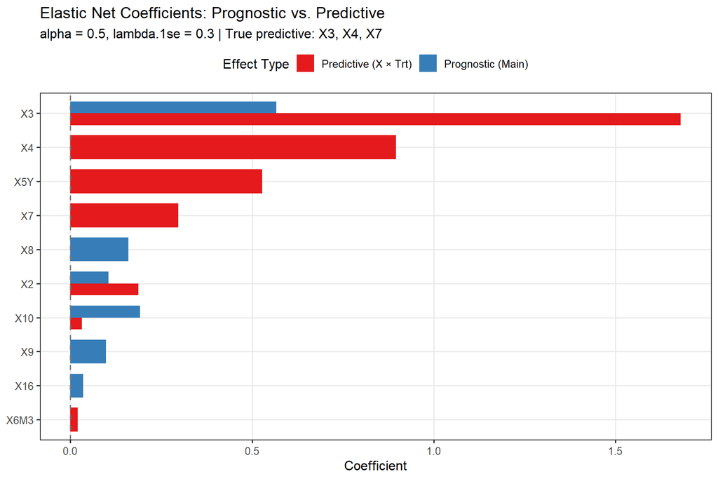

```r
# Coefficient plot: prognostic vs predictive effects side by side
if (nrow(coef_df) > 0) {
  ggplot(coef_df, aes(x = reorder(base_var, abs(coefficient)), y = coefficient, fill = type)) +
    geom_col(position = "dodge", width = 0.7) +
    coord_flip() +
    geom_hline(yintercept = 0, linetype = "dashed", color = "grey50") +
    scale_fill_manual(values = c("Prognostic (Main)" = "#377EB8", "Predictive (X × Trt)" = "#E41A1C")) +
    labs(
      title = "Elastic Net Coefficients: Prognostic vs. Predictive",
      subtitle = paste0("alpha = 0.5, lambda.1se = ", round(enet_fit$lambda.1se, 4),
                        " | True predictive: X3, X4, X7"),
      x = NULL, y = "Coefficient",
      fill = "Effect Type"
    ) +
    theme_bw(base_size = 12) +
    theme(
      panel.grid.minor = element_blank(),
      legend.position = "top"
    )
}
```

Overall, these results show that X3, X4, and X7 are likely predictive which is consistent with the true generating model. However, note that other truly non-predictive variables also get flagged as potentially predictive (e.g. X5=Y patients). Either way, if the decision was to take all covariates with non-zero coefficients (prognostic or predictive), this screening step would yield a total of 10 candidate covariates for downstream analyses.

In practice, the candidate set of covariates for heterogeneous treatment effect analyses is a crucial step and should by guided by prior data, domain expertise, biological plausibility, and practical implementation (e.g. can you use this factor to select patients?). Pre-specification of the candidate set in the Staistical Analysis Plan (SAP) can also increase credibility of any downstream result. For simplicity, the CATE and subgroup methods below will use the full set of 20 covariates.

# 6 CATE Estimation

Here, we highlight four different methods for estimating CATEs, which illustrates patient-level treatment heterogeneity. For meta-learner methods such as T/S/X learner, random forest (`ranger`) is used as the base-learner. Alternatively, instead of relying on a single model, model selection (via cross validation or bootstrap based loss functions) or ensemble models such as SuperLearner could also be used. Hyper-parameter tuning is also generally recommended.

## 6.1 S-Learner (Single Model)

The S-Learner fits a single model $\hat{\mu}(X, T)$ using treatment as a feature, then estimates:
$$\hat{\Delta}(x) =
\hat{\mu}(x, T=1) - \hat{\mu}(x, T=0)$$

```r
# S-Learner: fit one random forest on (X, trt) -> Y
dat_slearn <- data.frame(X_mat, trt = Trt, Y = Y)

rf_s <- ranger(Y ~ ., data = dat_slearn)

# Predict under trt=1 and trt=0 for each observation
newdata_1 <- data.frame(X_mat, trt = 1)
newdata_0 <- data.frame(X_mat, trt = 0)

cate_slearner <- predict(rf_s, data = newdata_1)$predictions -
                 predict(rf_s, data = newdata_0)$predictions

out <- c("S-Learner CATE summary:",
         capture.output(summary(cate_slearner)),
         paste("S-Learner MSE vs truth:", round(mean((cate_slearner - true_cate)^2), 4)))
cat(paste(out, collapse = "\n"), "\n")
```

```
## S-Learner CATE summary:
##    Min. 1st Qu.  Median    Mean 3rd Qu.    Max.
## -1.2765 -0.1011  0.4578  0.5729  1.2310  3.0104
## S-Learner MSE vs truth: 3.864
```

## 6.2 T-Learner (Two Models)

The T-Learner fits separate models for each treatment arm:
$$\hat{\Delta}(x) = \hat{\mu}_1(x) -
\hat{\mu}_0(x)$$

```r
# T-Learner: separate random forests for trt=1 and trt=0
dat_trt1 <- data.frame(X_mat[Trt == 1, , drop = FALSE], Y = Y[Trt == 1])
dat_trt0 <- data.frame(X_mat[Trt == 0, , drop = FALSE], Y = Y[Trt == 0])

rf_t1 <- ranger(Y ~ ., data = dat_trt1)
rf_t0 <- ranger(Y ~ ., data = dat_trt0)

# Predict CATE for all observations
cate_tlearner <- predict(rf_t1, data = data.frame(X_mat))$predictions -
                 predict(rf_t0, data = data.frame(X_mat))$predictions

out <- c("T-Learner CATE summary:",
         capture.output(summary(cate_tlearner)),
         paste("T-Learner MSE vs truth:", round(mean((cate_tlearner - true_cate)^2), 4)))
cat(paste(out, collapse = "\n"), "\n")
```

```
## T-Learner CATE summary:
##    Min. 1st Qu.  Median    Mean 3rd Qu.    Max.
## -5.4530 -0.3843  1.1610  0.9543  2.4748  6.4195
## T-Learner MSE vs truth: 2.0315
```

## 6.3 X-Learner

The X-Learner (Künzel et al., 2019) improves on the T-Learner by using cross-arm imputation of treatment effects. The procedure has three stages:

1. Stage 1 — Fit separate outcome models for each arm (like the T-Learner):
   $$\hat{\mu}_0(x) = \hat{E}[Y \mid
   X=x, T=0], \quad \hat{\mu}_1(x) = \hat{E}[Y \mid X=x,
   T=1]$$
2. Stage 2 — Impute individual treatment effects using the *other* arm’s model:
   $$\tilde{D}_i^1 =
   Y_i^1 - \hat{\mu}_0(X_i) \quad \text{for treated} \qquad \tilde{D}_i^0 =
   \hat{\mu}_1(X_i) - Y_i^0 \quad \text{for control}$$
   Then fit CATE models $\hat{\Delta}_1(x)$ and $\hat{\Delta}_0(x)$ on each set of imputed effects.
3. Stage 3 — Combine using propensity score weighting:
   $$\hat{\Delta}(x) = g(x) \cdot \hat{\Delta}_0(x) +
   (1 - g(x)) \cdot \hat{\Delta}_1(x)$$
   where $g(x) = P(T=1 \mid X=x)$ is the propensity score. In a randomized trial with 1:1 allocation, $g(x) = 0.5$, so the X-Learner simply averages the two CATE models.

The X-Learner is particularly effective when treatment arms are unbalanced (the larger arm’s model imputes more precise effects for the smaller arm), but it can still improve over the T-Learner even under balance by pooling information.

```r
# Stage 1: Fit separate outcome models (same as T-Learner)
# We reuse rf_t1 and rf_t0 from the T-Learner section

# Stage 2: Impute treatment effects via cross-arm prediction
# For treated subjects: D_1 = Y_1 - mu_0(X_1)
D_treated <- Y[Trt == 1] - predict(rf_t0, data = data.frame(X_mat[Trt == 1, , drop = FALSE]))$predictions

# For control subjects: D_0 = mu_1(X_0) - Y_0
D_control <- predict(rf_t1, data = data.frame(X_mat[Trt == 0, , drop = FALSE]))$predictions - Y[Trt == 0]

# Fit CATE models on imputed effects
rf_tau1 <- ranger(D ~ ., data = data.frame(X_mat[Trt == 1, , drop = FALSE], D = D_treated))
rf_tau0 <- ranger(D ~ ., data = data.frame(X_mat[Trt == 0, , drop = FALSE], D = D_control))

# Stage 3: Combine with propensity weighting
# In 1:1 RCT, g(x) = 0.5, so this is simply the average
tau_from_treated <- predict(rf_tau1, data = data.frame(X_mat))$predictions
tau_from_control <- predict(rf_tau0, data = data.frame(X_mat))$predictions

g_x <- 0.5  # propensity score under 1:1 randomization
cate_xlearner <- g_x * tau_from_control + (1 - g_x) * tau_from_treated

out <- c("X-Learner CATE summary:",
         capture.output(summary(cate_xlearner)),
         paste("X-Learner MSE vs truth:", round(mean((cate_xlearner - true_cate)^2), 4)))
cat(paste(out, collapse = "\n"), "\n")
```

```
## X-Learner CATE summary:
##    Min. 1st Qu.  Median    Mean 3rd Qu.    Max.
## -3.1903 -0.1323  1.0823  0.9243  2.1513  4.3796
## X-Learner MSE vs truth: 1.8746
```

## 6.4 Causal Forest (grf)

The Causal Forest from `grf` directly targets $\Delta(x) = E[Y(1) - Y(0) \mid X = x]$ via honest estimation with forest-based adaptive neighborhoods. A nice bonus of this package is built-in variable importance, which roughly looks at how often a covariate or feature was used for tree splits.

```r
cf <- causal_forest(
  X = X_mat, Y = Y, W = Trt,
  num.trees = 2000,
  honesty = TRUE,
  tune.parameters = "all"
)

cate_cf <- predict(cf)$predictions

out <- c("Causal Forest CATE summary:",
         capture.output(summary(cate_cf)),
         paste("Causal Forest MSE vs truth:", round(mean((cate_cf - true_cate)^2), 4)))
cat(paste(out, collapse = "\n"), "\n")
```

```
## Causal Forest CATE summary:
##    Min. 1st Qu.  Median    Mean 3rd Qu.    Max.
## -3.0723 -0.3911  1.0812  0.9127  2.3532  3.7029
## Causal Forest MSE vs truth: 1.3397
```

```r
# Variable importance from causal forest
varimp_cf <- variable_importance(cf)
varimp_df <- data.frame(
  variable = colnames(X_mat),
  importance = as.numeric(varimp_cf)
) %>% arrange(desc(importance))
```

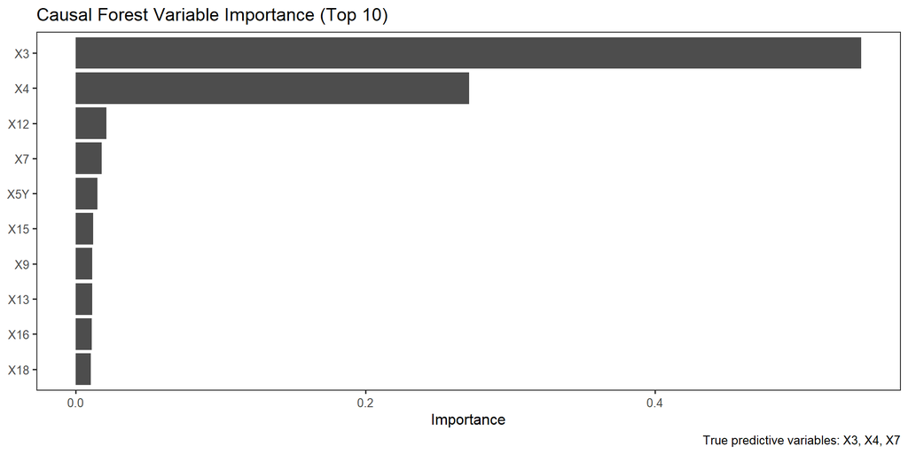

```r
# Variable importance from causal forest
top_vars <- head(varimp_df, 10)
ggplot(top_vars, aes(x = reorder(variable, importance), y = importance)) +
  geom_col(fill = "grey30") +
  coord_flip() +
  labs(
    title = "Causal Forest Variable Importance (Top 10)",
    x = NULL, y = "Importance",
    caption = "True predictive variables: X3, X4, X7"
  ) +
  theme_bw(base_size = 12) +
  theme(panel.grid = element_blank())
```

## 6.5 Compare CATE Estimates

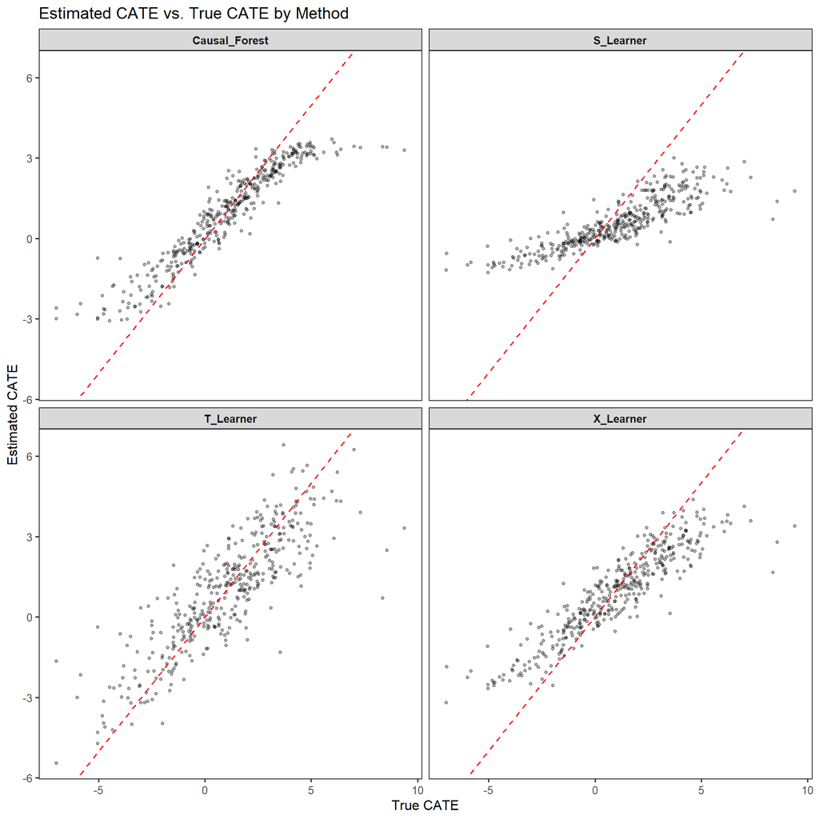

```r
cate_df <- data.frame(
  true_cate = true_cate,
  S_Learner = cate_slearner,
  T_Learner = cate_tlearner,
  Causal_Forest = cate_cf,
  X_Learner = cate_xlearner
) %>%
  pivot_longer(cols = -true_cate, names_to = "Method", values_to = "Estimated_CATE")

# Scatter: estimated vs true
ggplot(cate_df, aes(x = true_cate, y = Estimated_CATE)) +
  geom_point(alpha = 0.3, size = 1) +
  geom_abline(slope = 1, intercept = 0, linetype = "dashed", color = "red") +
  facet_wrap(~ Method, ncol = 2) +
  labs(
    title = "Estimated CATE vs. True CATE by Method",
    x = "True CATE",
    y = "Estimated CATE"
  ) +
  theme_bw(base_size = 12) +
  theme(panel.grid = element_blank(), strip.text = element_text(face = "bold"))
```

```r
mse_df <- data.frame(
  Method = c("S-Learner", "T-Learner", "Causal Forest", "X-Learner"),
  MSE = c(
    mean((cate_slearner - true_cate)^2),
    mean((cate_tlearner - true_cate)^2),
    mean((cate_cf - true_cate)^2),
    mean((cate_xlearner - true_cate)^2)
  ),
  Correlation = c(
    cor(cate_slearner, true_cate),
    cor(cate_tlearner, true_cate),
    cor(cate_cf, true_cate),
    cor(cate_xlearner, true_cate)
  )
)

knitr::kable(mse_df, digits = 4, caption = "CATE Estimation Performance")
```

CATE Estimation Performance

| Method | MSE | Correlation |
| --- | --- | --- |
| S-Learner | 3.8640 | 0.8583 |
| T-Learner | 2.0315 | 0.8443 |
| Causal Forest | 1.3397 | 0.9426 |
| X-Learner | 1.8746 | 0.9098 |

# 7 Subgroup Identification

This section focuses on identifying interpretable subgroups.

## 7.1 Virtual Twins

The Virtual Twins approach (Foster, Taylor, and Ruberg 2011) is a two-step procedure:

1. Step 1: Estimate individual-level CATEs (we use the X-Learner estimates)
2. Step 2: Fit a regression tree on the estimated CATEs to define subgroups

We limit the tree to `maxdepth = 2` (at most two levels of splits from the root, yielding up to 4 terminal nodes). This keeps the subgroup rules simple and interpretable, which is important for clinical communication.

```r
# Step 1: Use X-Learner CATE as the "virtual twin" difference
# (already computed above as cate_xlearner)

# Step 2: Fit a regression tree on CATEs to identify subgroups
vt_dat <- data.frame(X_covs, cate = cate_xlearner)

vt_tree <- rpart(
  cate ~ ., data = vt_dat,
  control = rpart.control(
    cp = 0.02,          # complexity parameter
    minsplit = 40,       # min obs to attempt split
    minbucket = 20,      # min obs in terminal node
    maxdepth = 2         # limit tree depth (root + 2 splits → max 4 leaves)
  )
)

# Print and plot the tree
out <- c("Virtual Twins Tree:", capture.output(print(vt_tree)))
cat(paste(out, collapse = "\n"), "\n")
```

```
## Virtual Twins Tree:
## n= 400
##
## node), split, n, deviance, yval
##       * denotes terminal node
##
## 1) root 400 1017.23700  0.924291500
##   2) X3< -0.3219378 140  150.63230 -0.694593400
##     4) X4< -0.6819347 65   36.39910 -1.507192000 *
##     5) X4>=-0.6819347 75   34.11483  0.009658688 *
##   3) X3>=-0.3219378 260  302.12770  1.795999000
##     6) X4< -0.2303606 68   32.98255  0.687011600 *
##     7) X4>=-0.2303606 192  155.89620  2.188765000 *
```

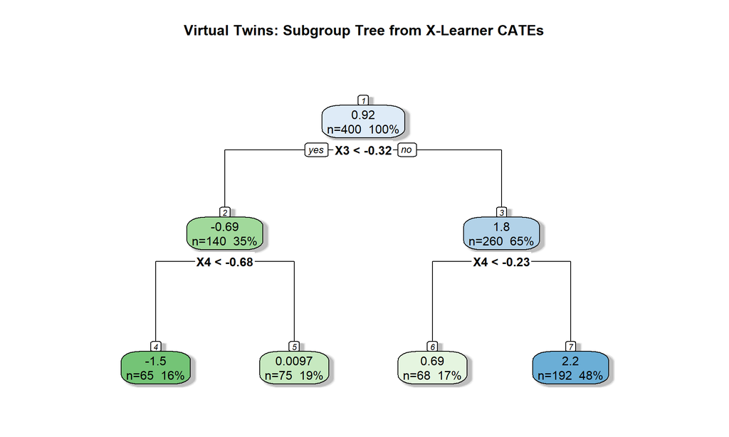

```r
rpart.plot(
  vt_tree,
  main = "Virtual Twins: Subgroup Tree from X-Learner CATEs",
  extra = 101,  # show n and percent
  box.palette = "GnBu",
  shadow.col = "gray",
  nn = TRUE
)
```

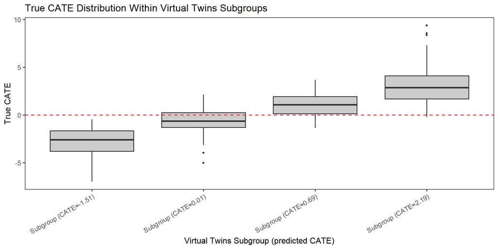

```r
# Assign subgroup labels
dat$vt_subgroup <- as.factor(predict(vt_tree, newdata = X_covs, type = "vector"))
dat$vt_subgroup_label <- paste0("Subgroup (CATE≈", round(as.numeric(as.character(dat$vt_subgroup)), 2), ")")

# Compare true CATEs within each VT subgroup
ggplot(dat, aes(x = vt_subgroup_label, y = trt_effect)) +
  geom_boxplot(fill = "grey80", outlier.size = 1) +
  geom_hline(yintercept = 0, linetype = "dashed", color = "red") +
  labs(
    title = "True CATE Distribution Within Virtual Twins Subgroups",
    x = "Virtual Twins Subgroup (predicted CATE)",
    y = "True CATE"
  ) +
  theme_bw(base_size = 12) +
  theme(
    panel.grid = element_blank(),
    axis.text.x = element_text(angle = 30, hjust = 1)
  )
```

## 7.2 X-Learner CATE Estimates

The following figure shows the X-Learner CATE estimates: estimated vs. true CATE (left) and a waterfall plot of the estimated CATEs ordered from smallest to largest (right). Patients are color-coded as “Benefitting” (estimated CATE > 0) or “Non-benefitting” (estimated CATE ≤ 0).

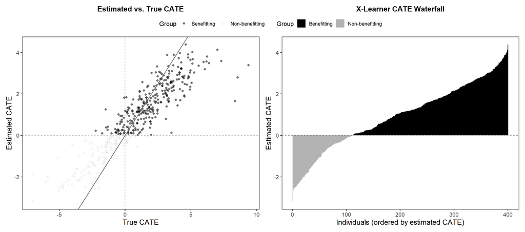

```r
# --- Build data ---
xlearner_plot_df <- data.frame(
  true_cate = true_cate,
  estimated_cate = cate_xlearner,
  benefit_group = ifelse(cate_xlearner > 0, "Benefitting", "Non-benefitting")
)

waterfall_df <- xlearner_plot_df %>%
  arrange(estimated_cate) %>%
  mutate(order = row_number())

color_vals <- c("Benefitting" = "black", "Non-benefitting" = "grey70")
shape_vals <- c("Benefitting" = 16, "Non-benefitting" = 1)

# --- Left panel: Estimated vs True CATE ---
p_scatter <- ggplot(xlearner_plot_df, aes(x = true_cate, y = estimated_cate,
                                           color = benefit_group, shape = benefit_group)) +
  geom_point(alpha = 0.55, size = 1.8, stroke = 0.5) +
  geom_abline(slope = 1, intercept = 0, linetype = "solid", color = "grey40", linewidth = 0.7) +
  geom_hline(yintercept = 0, linetype = "dashed", color = "grey60", linewidth = 0.5) +
  geom_vline(xintercept = 0, linetype = "dashed", color = "grey60", linewidth = 0.5) +
  scale_color_manual(values = color_vals) +
  scale_shape_manual(values = shape_vals) +
  labs(
    title = "Estimated vs. True CATE",
    x = "True CATE",
    y = "Estimated CATE",
    color = "Group", shape = "Group"
  ) +
  theme_bw(base_size = 12) +
  theme(
    panel.grid = element_blank(),
    legend.position = "top",
    plot.title = element_text(size = 14, face = "bold", hjust = 0.5),
    axis.title = element_text(size = 14),
    axis.text = element_text(size = 11)
  )

# --- Right panel: Waterfall plot ---
p_waterfall <- ggplot(waterfall_df, aes(x = order, y = estimated_cate, fill = benefit_group)) +
  geom_bar(stat = "identity", width = 1, color = NA) +
  geom_hline(yintercept = 0, linetype = "dashed", color = "grey40", linewidth = 0.5) +
  scale_fill_manual(values = color_vals) +
  labs(
    title = "X-Learner CATE Waterfall",
    x = "Individuals (ordered by estimated CATE)",
    y = "Estimated CATE",
    fill = "Group"
  ) +
  theme_bw(base_size = 12) +
  theme(
    panel.grid = element_blank(),
    legend.position = "top",
    plot.title = element_text(size = 14, face = "bold", hjust = 0.5),
    axis.title = element_text(size = 14),
    axis.text = element_text(size = 11)
  )

# --- Combine ---
p_xlearner_fig52 <- p_scatter + p_waterfall +
  plot_layout(ncol = 2, guides = "collect") &
  theme(legend.position = "top")

p_xlearner_fig52
```

## 7.3 Model-Based Recursive Partitioning (MOB)

```r
# Fit MOB: Y ~ trt (+ screened prognostic vars) | all X variables for partitioning
# We use the variables identified by elastic net screening as node covariates
mob_dat <- data.frame(Y = Y, trt = Trt, X_covs)

cov_names <- colnames(X_covs)

# Build MOB formula using elastic-net-selected variables in the node model
selected_vars <- selected_vars_enet
if (length(selected_vars) > 0) {
  node_vars <- intersect(selected_vars, cov_names)
  if (length(node_vars) > 0) {
    mob_formula <- as.formula(
      paste0("Y ~ trt + ", paste(node_vars, collapse = " + "), " | ",
             paste(cov_names, collapse = " + "))
    )
  } else {
    mob_formula <- as.formula(paste0("Y ~ trt | ", paste(cov_names, collapse = " + ")))
  }
} else {
  mob_formula <- as.formula(paste0("Y ~ trt | ", paste(cov_names, collapse = " + ")))
}

cat("MOB formula:", deparse(mob_formula), "\n")
```

```
## MOB formula: Y ~ trt + X2 + X3 + X8 + X9 + X10 + X16 + X4 + X5 + X6 + X7 |      X1 + X2 + X3 + X4 + X5 + X6 + X7 + X8 + X9 + X10 + X11 +          X12 + X13 + X14 + X15 + X16 + X17 + X18 + X19 + X20
```

```r
mob_tree <- glmtree(
  mob_formula,
  data = mob_dat,
  family = gaussian,
  parm = 2,                        # test instability in trt coefficient
  minsize = floor(0.15 * N),       # min node size (15% of N)
  maxdepth = 2L,                   # limit tree depth (root + 2 splits → max 4 leaves)
  alpha = 0.05,                    # significance level for splits
  bonferroni = TRUE                # adjust for multiple testing
)
# Estimate CATE from MOB
cate_mob <- predict(mob_tree, newdata = mob_dat %>% mutate(trt = 1), type = "response") -
            predict(mob_tree, newdata = mob_dat %>% mutate(trt = 0), type = "response")
```

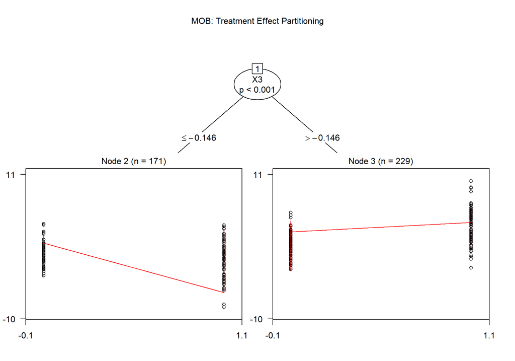

```r
plot(mob_tree, main = "MOB: Treatment Effect Partitioning",
     tp_args = list(which = "trt"))
```

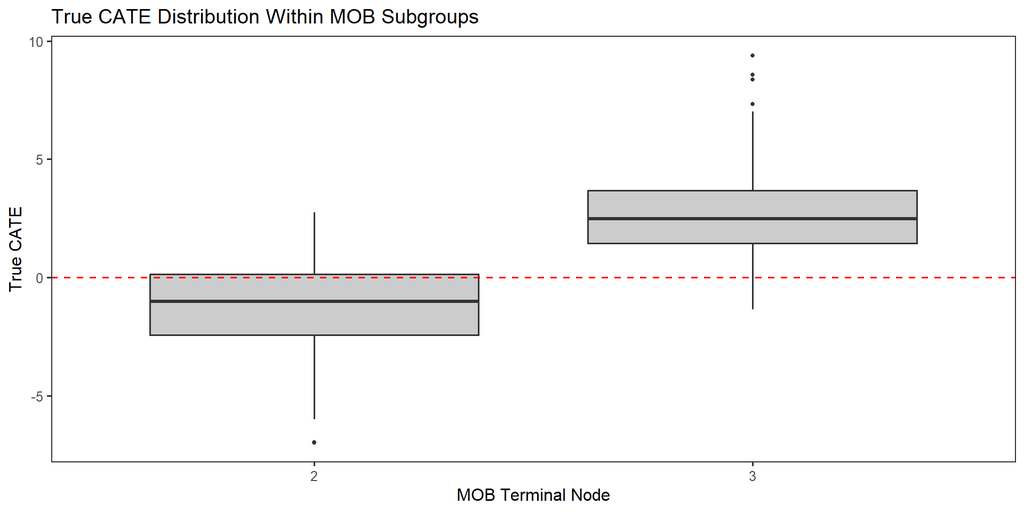

```r
dat$mob_node <- predict(mob_tree, type = "node")
ggplot(dat, aes(x = factor(mob_node), y = trt_effect)) +
  geom_boxplot(fill = "grey80", outlier.size = 1) +
  geom_hline(yintercept = 0, linetype = "dashed", color = "red") +
  labs(
    title = "True CATE Distribution Within MOB Subgroups",
    x = "MOB Terminal Node",
    y = "True CATE"
  ) +
  theme_bw(base_size = 12) +
  theme(panel.grid = element_blank())
```

## 7.4 `personalized` Package (Linear Regression Learner)

The [`personalized`](https://CRAN.R-project.org/package=personalized) package (Huling and Yu 2024; Chen et al. 2017) provides a unified framework for subgroup identification and treatment effect estimation. Here, we use linear regression as the outcome model. This produces a model-based subgroup rule and the estimated CATE is a linear function of covariates. and the sign of the prediction determines whether a patient is classified as “Benefitting” or “Non-Benefitting.”

The key steps:

The advantage of a linear learner is interpretability — the subgroup rule is a weighted combination of covariates, not an opaque tree or forest.

```r
# Prepare data for personalized package
# The package expects: x (covariate matrix), trt (0/1 or -1/1), y (outcome)
# We'll use the numeric model matrix
X_pers <- X_mat

# Fit propensity score model (logistic regression)
propensity_func <- function(x, trt) {
  df <- data.frame(trt = trt, x)
  fit <- glm(trt ~ ., data = df, family = binomial)
  predict(fit, type = "response")
}

# Fit the personalized model with linear regression as the outcome learner
# loss = "sq_loss_lasso" uses penalized linear regression for the contrast function
pers_fit <- fit.subgroup(
  x = X_pers,
  y = Y,
  trt = Trt,
  propensity.func = propensity_func,
  loss = "sq_loss_lasso",  # linear (lasso-penalized) outcome model
  nfolds = 5               # CV folds for lasso tuning
)

out <- c("Personalized model summary:", capture.output(print(pers_fit)))
cat(paste(out, collapse = "\n"), "\n")
```

```
## Personalized model summary:
## family:    gaussian
## loss:      sq_loss_lasso
## method:    weighting
## cutpoint:  0
## propensity
## function:  propensity.func
##
## benefit score: f(x),
## Trt recom = 1*I(f(x)>c)+0*I(f(x)<=c) where c is 'cutpoint'
##
## Average Outcomes:
##               Recommended 0    Recommended 1
## Received 0 -0.4919 (n = 62)  0.768 (n = 138)
## Received 1 -2.6094 (n = 57) 2.9029 (n = 143)
##
## Treatment effects conditional on subgroups:
## Est of E[Y|T=0,Recom=0]-E[Y|T=/=0,Recom=0]
##                           2.1175 (n = 119)
## Est of E[Y|T=1,Recom=1]-E[Y|T=/=1,Recom=1]
##                           2.1349 (n = 281)
##
## NOTE: The above average outcomes are biased estimates of
##       the expected outcomes conditional on subgroups.
##       Use 'validate.subgroup()' to obtain unbiased estimates.
##
## ---------------------------------------------------
##
## Benefit score quantiles (f(X) for 1 vs 0):
##      0%     25%     50%     75%    100%
## -2.6992 -0.1581  0.5189  1.1435  3.7448
##
## ---------------------------------------------------
##
## Summary of individual treatment effects:
## E[Y|T=1, X] - E[Y|T=0, X]
##
##    Min. 1st Qu.  Median    Mean 3rd Qu.    Max.
## -5.3984 -0.3161  1.0379  0.9156  2.2869  7.4895
```

```r
# Extract subgroup assignments: personalized assigns "Recommended trt"
# benefit.scores > 0 => recommend treatment (Benefitting)
# benefit.scores <= 0 => recommend control (Non-Benefitting)
dat$pers_benefit_score <- pers_fit$benefit.scores
dat$pers_subgroup <- ifelse(pers_fit$benefit.scores > 0, "B", "NB")

out <- c("Personalized subgroup counts:",
         capture.output(print(table(dat$pers_subgroup))))
cat(paste(out, collapse = "\n"), "\n")
```

```
## Personalized subgroup counts:
##
##   B  NB
## 281 119
```

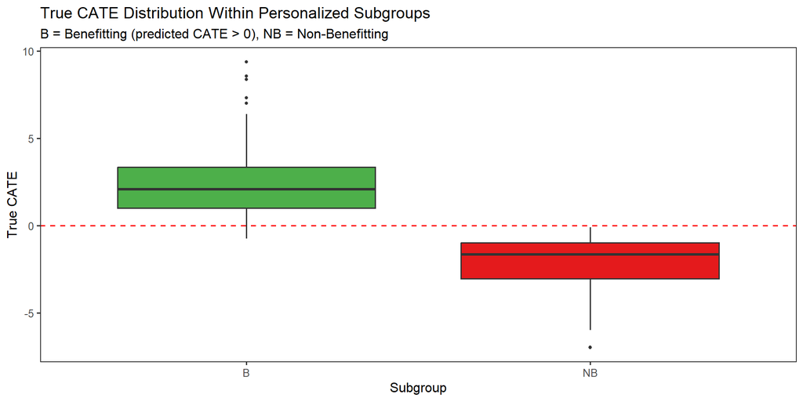

```r
# Boxplot of true CATEs by Personalized subgroup
ggplot(dat, aes(x = pers_subgroup, y = trt_effect, fill = pers_subgroup)) +
  geom_boxplot(outlier.size = 1) +
  geom_hline(yintercept = 0, linetype = "dashed", color = "red") +
  scale_fill_manual(values = c("B" = "#4DAF4A", "NB" = "#E41A1C"), guide = "none") +
  labs(
    title = "True CATE Distribution Within Personalized Subgroups",
    subtitle = "B = Benefitting (predicted CATE > 0), NB = Non-Benefitting",
    x = "Subgroup", y = "True CATE"
  ) +
  theme_bw(base_size = 12) +
  theme(panel.grid = element_blank())
```

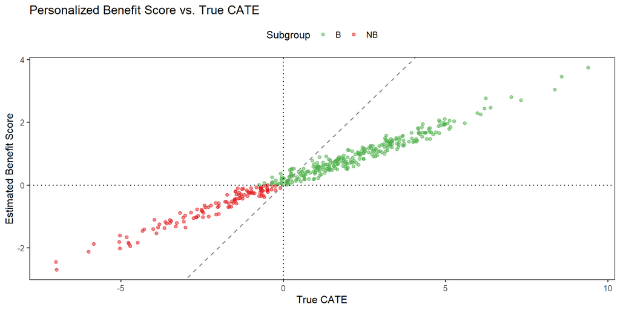

```r
# Scatter: personalized benefit score vs true CATE
ggplot(dat, aes(x = trt_effect, y = pers_benefit_score, color = pers_subgroup)) +
  geom_point(alpha = 0.5, size = 1.5) +
  geom_abline(slope = 1, intercept = 0, linetype = "dashed", color = "grey50") +
  geom_hline(yintercept = 0, linetype = "dotted") +
  geom_vline(xintercept = 0, linetype = "dotted") +
  scale_color_manual(values = c("B" = "#4DAF4A", "NB" = "#E41A1C")) +
  labs(
    title = "Personalized Benefit Score vs. True CATE",
    x = "True CATE", y = "Estimated Benefit Score",
    color = "Subgroup"
  ) +
  theme_bw(base_size = 12) +
  theme(panel.grid = element_blank(), legend.position = "top")
```

## 7.5 Benefitting vs. Non-Benefitting

For practical implementation, it is often needed to classify which patients should receive the treatment and which shouldn’t. This can guide decision making for subsequent clinical trials. To do this, subgroup assignments are collapsed into the following groups:

- “B” (Benefitting): subgroup-level mean CATE > 0 (treatment is beneficial on average)
- “NB” (Non-Benefitting): subgroup-level mean CATE ≤ 0 (treatment is not beneficial on average)

```r
# --- Virtual Twins: classify leaves as B/NB based on mean predicted CATE ---
vt_leaf <- as.character(vt_tree$where)
vt_leaf_mean_cate <- tapply(cate_xlearner, vt_leaf, mean)
vt_leaf_class <- ifelse(vt_leaf_mean_cate > 0, "B", "NB")
dat$vt_binary <- vt_leaf_class[vt_leaf]

# --- MOB: classify nodes as B/NB based on mean predicted CATE ---
mob_nodes <- as.character(predict(mob_tree, type = "node"))
mob_node_mean_cate <- tapply(cate_mob, mob_nodes, mean)
mob_node_class <- ifelse(mob_node_mean_cate > 0, "B", "NB")
dat$mob_binary <- mob_node_class[mob_nodes]

# --- Personalized: already have binary from benefit score sign ---
# dat$pers_subgroup already set above

# ============================================================
# Summarize subgroup rules for each method
# ============================================================

# Build all output lines, then print once for clean knitted output
out <- character()
out <- c(out, "=== Subgroup Rules: B (Benefitting) vs. NB (Non-Benefitting) ===", "")

# --- Virtual Twins ---
out <- c(out, "--- Virtual Twins ---")
vt_rules <- rpart.rules(vt_tree, style = "tall")
vt_rules_df <- data.frame(
  leaf = rownames(vt_rules),
  rule = apply(vt_rules, 1, function(r) paste(trimws(r), collapse = " ")),
  stringsAsFactors = FALSE
)
# Remove "when" from rule text and map to B/NB
vt_rules_df$rule <- gsub(" when ", " ", vt_rules_df$rule)
for (i in seq_len(nrow(vt_rules_df))) {
  leaf_id <- as.character(which(rownames(vt_tree$frame) == vt_rules_df$leaf[i]))
  label <- vt_leaf_class[leaf_id]
  n_leaf <- sum(vt_leaf == leaf_id)
  out <- c(out, paste0("  ", label, ": ", vt_rules_df$rule[i], "  (n = ", n_leaf, ")"))
}
out <- c(out, "")

# --- MOB ---
out <- c(out, "--- MOB ---")
mob_rules <- partykit:::.list.rules.party(mob_tree)
# Round numeric split values in rule text
round_numbers_in_text <- function(txt, digits = 2) {
  m <- gregexpr("-?\\d+\\.\\d+", txt, perl = TRUE)
  regmatches(txt, m) <- lapply(regmatches(txt, m), function(x) {
    round(as.numeric(x), digits)
  })
  txt
}
mob_rules <- sapply(mob_rules, round_numbers_in_text)
for (nid in names(mob_rules)) {
  label <- mob_node_class[nid]
  mean_cate <- round(mob_node_mean_cate[nid], 2)
  n_node <- sum(mob_nodes == nid)
  rule_text <- mob_rules[nid]
  out <- c(out, paste0("  ", label, ": ", rule_text, "  (mean CATE = ", mean_cate,
                        ", n = ", n_node, ")"))
}
out <- c(out, "")

# --- Personalized ---
pers_coefs <- coef(pers_fit$model)
nonzero_idx <- which(pers_coefs != 0)
out <- c(out,
  "--- Personalized ---",
  paste0("  B: benefit score > 0  (n = ", sum(dat$pers_subgroup == "B"), ")"),
  paste0("  NB: benefit score <= 0  (n = ", sum(dat$pers_subgroup == "NB"), ")"),
  "  Benefit score is a linear combination of covariates (lasso).",
  "  Non-zero coefficients:"
)
if (length(nonzero_idx) > 0) {
  nonzero_coefs <- pers_coefs[nonzero_idx]
  names(nonzero_coefs) <- rownames(pers_coefs)[nonzero_idx]
  for (nm in names(sort(abs(nonzero_coefs), decreasing = TRUE))) {
    out <- c(out, paste0("    ", nm, " = ", round(nonzero_coefs[nm], 4)))
  }
}

cat(paste(out, collapse = "\n"), "\n")
```

```
## === Subgroup Rules: B (Benefitting) vs. NB (Non-Benefitting) ===
##
## --- Virtual Twins ---
##   NB: -1.5072 X3 < -0.32 & X4 < -0.68  (n = 65)
##   B: 0.0097 X3 < -0.32 & X4 >= -0.68  (n = 75)
##   B: 0.6870 X3 >= -0.32 & X4 < -0.23  (n = 68)
##   B: 2.1888 X3 >= -0.32 & X4 >= -0.23  (n = 192)
##
## --- MOB ---
##   NB: X3 <= -0.15  (mean CATE = -1.47, n = 171)
##   B: X3 > -0.15  (mean CATE = 2.65, n = 229)
##
## --- Personalized ---
##   B: benefit score > 0  (n = 281)
##   NB: benefit score <= 0  (n = 119)
##   Benefit score is a linear combination of covariates (lasso).
##   Non-zero coefficients:
##     Trt1 = 0.4508
##     X3 = 0.3708
##     X4 = 0.1732
```

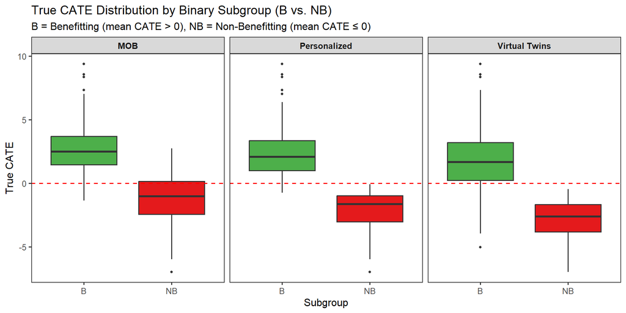

```r
# Compare true CATE distributions across methods
binary_df <- dat %>%
  select(trt_effect, vt_binary, mob_binary, pers_subgroup) %>%
  pivot_longer(cols = c(vt_binary, mob_binary, pers_subgroup),
               names_to = "method", values_to = "subgroup") %>%
  mutate(method = recode(method,
    "vt_binary" = "Virtual Twins",
    "mob_binary" = "MOB",
    "pers_subgroup" = "Personalized"
  ))

ggplot(binary_df, aes(x = subgroup, y = trt_effect, fill = subgroup)) +
  geom_boxplot(outlier.size = 1) +
  geom_hline(yintercept = 0, linetype = "dashed", color = "red") +
  facet_wrap(~ method) +
  scale_fill_manual(values = c("B" = "#4DAF4A", "NB" = "#E41A1C"), guide = "none") +
  labs(
    title = "True CATE Distribution by Binary Subgroup (B vs. NB)",
    subtitle = "B = Benefitting (mean CATE > 0), NB = Non-Benefitting (mean CATE ≤ 0)",
    x = "Subgroup", y = "True CATE"
  ) +
  theme_bw(base_size = 12) +
  theme(panel.grid = element_blank(), strip.text = element_text(face = "bold"))
```

# 8 Subgroup-Level Treatment Effect Estimation

## 8.1 Reusable Functions

```r
# ============================================================
# CATE Estimation Functions
# ============================================================

#' X-Learner CATE estimation
#' @param Y outcome vector
#' @param Trt treatment indicator (0/1)
#' @param X_mat numeric covariate matrix
#' @param X_mat_pred covariate matrix for prediction (default: X_mat)
#' @return vector of CATE estimates (one per row of X_mat_pred)
estimate_cate_xlearner <- function(Y, Trt, X_mat, X_mat_pred = X_mat) {
  # Stage 1: fit separate outcome models
  dat_trt <- data.frame(X_mat[Trt == 1, , drop = FALSE], Y = Y[Trt == 1])
  dat_ctl <- data.frame(X_mat[Trt == 0, , drop = FALSE], Y = Y[Trt == 0])

  rf1 <- ranger(Y ~ ., data = dat_trt, num.trees = 500, min.node.size = 5)
  rf0 <- ranger(Y ~ ., data = dat_ctl, num.trees = 500, min.node.size = 5)

  # Stage 2: cross-arm imputation
  D_treated <- Y[Trt == 1] - predict(rf0, data = data.frame(X_mat[Trt == 1, , drop = FALSE]))$predictions
  D_control <- predict(rf1, data = data.frame(X_mat[Trt == 0, , drop = FALSE]))$predictions - Y[Trt == 0]

  rf_tau1 <- ranger(D ~ ., data = data.frame(X_mat[Trt == 1, , drop = FALSE], D = D_treated),
                    num.trees = 500, min.node.size = 5)
  rf_tau0 <- ranger(D ~ ., data = data.frame(X_mat[Trt == 0, , drop = FALSE], D = D_control),
                    num.trees = 500, min.node.size = 5)

  # Stage 3: combine with propensity weighting (g=0.5 for 1:1 RCT)
  tau_from_treated <- predict(rf_tau1, data = data.frame(X_mat_pred))$predictions
  tau_from_control <- predict(rf_tau0, data = data.frame(X_mat_pred))$predictions

  0.5 * tau_from_control + 0.5 * tau_from_treated
}

# ============================================================
# Subgroup Identification Functions
# Each returns a character vector of "B" or "NB" for each observation
# ============================================================

#' Virtual Twins subgroup identification
#' @param cate vector of CATE estimates
#' @param X_covs data frame of covariates
#' @return character vector "B"/"NB" for each observation
identify_subgroups_vt <- function(cate, X_covs) {
  vt_dat <- data.frame(X_covs, cate = cate)
  tree <- rpart(
    cate ~ ., data = vt_dat,
    control = rpart.control(cp = 0.02, minsplit = 40, minbucket = 20, maxdepth = 2)
  )
  leaf <- as.character(tree$where)
  leaf_mean <- tapply(cate, leaf, mean)
  leaf_class <- ifelse(leaf_mean > 0, "B", "NB")
  leaf_class[leaf]
}

#' MOB subgroup identification
#' @param Y outcome vector
#' @param Trt treatment indicator
#' @param X_covs data frame of covariates
#' @return character vector "B"/"NB" for each observation
identify_subgroups_mob <- function(Y, Trt, X_covs) {
  mob_dat <- data.frame(Y = Y, trt = Trt, X_covs)
  cov_names <- colnames(X_covs)

  # Use simple Y ~ trt | X formula (skip lasso for bootstrap speed)
  mob_formula <- as.formula(paste0("Y ~ trt | ", paste(cov_names, collapse = " + ")))

  tree <- tryCatch(
    glmtree(mob_formula, data = mob_dat, family = gaussian,
            parm = 2, minsize = floor(0.15 * nrow(mob_dat)),
            maxdepth = 2L, alpha = 0.05, bonferroni = TRUE),
    error = function(e) NULL
  )

  if (is.null(tree)) {
    # If MOB fails to split, assign everyone to "B"
    return(rep("B", nrow(mob_dat)))
  }

  # Get CATE per node
  cate_mob <- predict(tree, newdata = mob_dat %>% mutate(trt = 1), type = "response") -
              predict(tree, newdata = mob_dat %>% mutate(trt = 0), type = "response")
  nodes <- as.character(predict(tree, type = "node"))
  node_mean <- tapply(cate_mob, nodes, mean)
  node_class <- ifelse(node_mean > 0, "B", "NB")
  node_class[nodes]
}

#' Personalized (lasso LM) subgroup identification
#' @param Y outcome vector
#' @param Trt treatment indicator
#' @param X_mat numeric covariate matrix
#' @return character vector "B"/"NB" for each observation
identify_subgroups_personalized <- function(Y, Trt, X_mat) {
  prop_func <- function(x, trt) {
    df <- data.frame(trt = trt, x)
    fit <- glm(trt ~ ., data = df, family = binomial)
    predict(fit, type = "response")
  }

  fit <- tryCatch(
    fit.subgroup(x = X_mat, y = Y, trt = Trt,
                 propensity.func = prop_func,
                 loss = "sq_loss_lasso", nfolds = 5),
    error = function(e) NULL
  )

  if (is.null(fit)) return(rep("B", length(Y)))
  ifelse(fit$benefit.scores > 0, "B", "NB")
}

# ============================================================
# Subgroup Treatment Effect Estimation (Naive)
# ============================================================

#' Compute naive treatment effect within binary subgroups using lm(Y ~ Trt)
#' @param Y outcome
#' @param Trt treatment indicator
#' @param subgroup character vector of "B"/"NB"
#' @return named vector: c(B = effect_B, NB = effect_NB)
subgroup_effects_naive <- function(Y, Trt, subgroup) {
  result <- c(B = NA_real_, NB = NA_real_)
  for (s in c("B", "NB")) {
    idx <- subgroup == s
    if (sum(idx & Trt == 1) > 1 && sum(idx & Trt == 0) > 1) {
      fit <- lm(Y[idx] ~ Trt[idx])
      result[s] <- coef(fit)["Trt[idx]"]
    }
  }
  result
}
```

## 8.2 Naive Estimator

The naive estimator computes the unadjusted difference in means between treatment arms within each binary subgroup, equivalent to fitting `lm(Y ~ trt)` within each subgroup. In general, this approach does not account for the subgroup identification process and is not recommended.

```r
# Compute naive estimates for each subgroup method using lm(Y ~ Trt)
naive_results <- data.frame()

for (sg_method in c("Virtual Twins", "MOB", "Personalized")) {
  sg_col <- switch(sg_method,
    "Virtual Twins" = "vt_binary",
    "MOB" = "mob_binary",
    "Personalized" = "pers_subgroup"
  )

  for (s in c("B", "NB")) {
    idx <- dat[[sg_col]] == s
    n_s <- sum(idx)
    n_trt <- sum(idx & Trt == 1)
    n_ctl <- sum(idx & Trt == 0)

    if (n_trt > 1 & n_ctl > 1) {
      fit <- lm(Y[idx] ~ Trt[idx])
      est <- coef(fit)["Trt[idx]"]
      se  <- summary(fit)$coefficients["Trt[idx]", "Std. Error"]
      ci  <- confint(fit)["Trt[idx]", ]
      true_ate <- mean(true_cate[idx])

      naive_results <- bind_rows(naive_results, data.frame(
        sg_method = sg_method, subgroup = s, n = n_s,
        estimate = est, se = se,
        lower = ci[1],
        upper = ci[2],
        true_ate = true_ate,
        est_method = "Naive"
      ))
    }
  }
}
```

## 8.3 Bootstrap (Refit all)

This approach uses bootstrap resampling (e.g. `boot::boot()`) to construct subgroup-specific CIs that account for the uncertainty in CATE estimation and subgroup identification. For each bootstrap resample:

1. Re-estimate CATEs (X-Learner)
2. Re-run the subgroup identification model (VT, MOB, or Personalized)
3. Re-classify into B/NB based on the new subgroup model
4. Compute $E[Y \mid \text{Trt}=1, S=s] - E[Y \mid \text{Trt}=0, S=s]$ for each subgroup

This yields a bootstrap distribution of subgroup estimates. Following Foster, Taylor, and Ruberg (2011), the bootstrap bias-corrected estimate is $\hat{\Delta}_{BC} = 2\hat{\Delta} - \bar{\Delta}^{*}$, where $\hat{\Delta}$ is the original-sample estimate and $\bar{\Delta}^{*}$ is the bootstrap mean. This corrects for the optimistic bias that arises when the same data are used to both identify subgroups and estimate effects within them. For results throughout, 95% CIs are obtained via percentile method.

```r
# Boot statistic functions for each subgroup method.
# Each calls the reusable functions defined above (estimate_cate_xlearner,
# identify_subgroups_*, subgroup_effects_naive) to ensure consistent
# tuning parameters between the original fit and bootstrap resamples.
# Returns: c(effect_B, effect_NB)

boot_stat_vt <- function(data, indices) {
  d <- data[indices, ]
  Y_b <- d$Y; Trt_b <- d$Trt
  X_mat_b <- as.matrix(d[, grep("^X", colnames(d))])
  X_covs_b <- d[, grep("^X", colnames(d)), drop = FALSE]

  # Re-estimate CATEs via X-Learner
  cate_b <- estimate_cate_xlearner(Y_b, Trt_b, X_mat_b)

  # Re-identify subgroups
  sg_b <- identify_subgroups_vt(cate_b, X_covs_b)

  # Compute subgroup effects
  subgroup_effects_naive(Y_b, Trt_b, sg_b)
}

boot_stat_mob <- function(data, indices) {
  d <- data[indices, ]
  Y_b <- d$Y; Trt_b <- d$Trt
  X_covs_b <- d[, grep("^X", colnames(d)), drop = FALSE]

  # MOB re-identification (CATE is estimated internally by MOB)
  sg_b <- identify_subgroups_mob(Y_b, Trt_b, X_covs_b)

  # Compute subgroup effects
  subgroup_effects_naive(Y_b, Trt_b, sg_b)
}

boot_stat_pers <- function(data, indices) {
  d <- data[indices, ]
  Y_b <- d$Y; Trt_b <- d$Trt
  X_mat_b <- as.matrix(d[, grep("^X", colnames(d))])

  # Re-identify subgroups
  sg_b <- identify_subgroups_personalized(Y_b, Trt_b, X_mat_b)

  # Compute subgroup effects
  subgroup_effects_naive(Y_b, Trt_b, sg_b)
}
```

```r
# Prepare data for boot (combine Y, Trt, and covariates)
boot_data <- data.frame(Y = Y, Trt = Trt, X_mat)

B_boot <- 200  # bootstrap replicates (balance computation vs. precision)

set.seed(2026)

cat("Running bootstrap for Virtual Twins...\n")
```

```
## Running bootstrap for Virtual Twins...
```

```r
boot_vt <- boot(data = boot_data, statistic = boot_stat_vt, R = B_boot)

cat("Running bootstrap for MOB...\n")
```

```
## Running bootstrap for MOB...
```

```r
boot_mob <- boot(data = boot_data, statistic = boot_stat_mob, R = B_boot)

cat("Running bootstrap for Personalized...\n")
```

```
## Running bootstrap for Personalized...
```

```r
boot_pers <- boot(data = boot_data, statistic = boot_stat_pers, R = B_boot)
```

```r
# Extract bootstrap CIs using percentile method.
# The forest plot uses the bootstrap mean as the point estimate.
# The summary table additionally reports the Foster et al. (2011)
# bias-corrected estimate: theta_BC = 2 * theta_hat - mean(theta_star).
extract_boot_ci <- function(boot_obj, sg_method, original_subgroups, true_cates) {
  results <- data.frame()

  for (i in 1:2) {
    s <- c("B", "NB")[i]

    # Get bootstrap CI (percentile method)
    ci <- tryCatch(
      boot.ci(boot_obj, index = i, type = "perc", conf = 0.95),
      error = function(e) NULL
    )

    # Bootstrap mean (observed) — used as point estimate in forest plot
    boot_mean <- mean(boot_obj$t[, i], na.rm = TRUE)
    # Bias-corrected estimate (Foster et al. 2011) — reported in summary table
    bias_corrected <- 2 * boot_obj$t0[i] - boot_mean
    se  <- sd(boot_obj$t[, i], na.rm = TRUE)

    if (!is.null(ci) && !is.null(ci$percent)) {
      lower <- ci$percent[4]
      upper <- ci$percent[5]
    } else {
      lower <- quantile(boot_obj$t[, i], 0.025, na.rm = TRUE)
      upper <- quantile(boot_obj$t[, i], 0.975, na.rm = TRUE)
    }

    true_ate <- mean(true_cates[original_subgroups == s])
    n_s <- sum(original_subgroups == s)

    results <- bind_rows(results, data.frame(
      sg_method = sg_method, subgroup = s, n = n_s,
      estimate = boot_mean, bias_corrected = bias_corrected, se = se,
      lower = lower, upper = upper,
      true_ate = true_ate,
      est_method = "Bootstrap (Refit)"
    ))
  }
  results
}

boot_results_vt <- extract_boot_ci(boot_vt, "Virtual Twins", dat$vt_binary, true_cate)
boot_results_mob <- extract_boot_ci(boot_mob, "MOB", dat$mob_binary, true_cate)
boot_results_pers <- extract_boot_ci(boot_pers, "Personalized", dat$pers_subgroup, true_cate)

boot_results <- bind_rows(boot_results_vt, boot_results_mob, boot_results_pers)
```

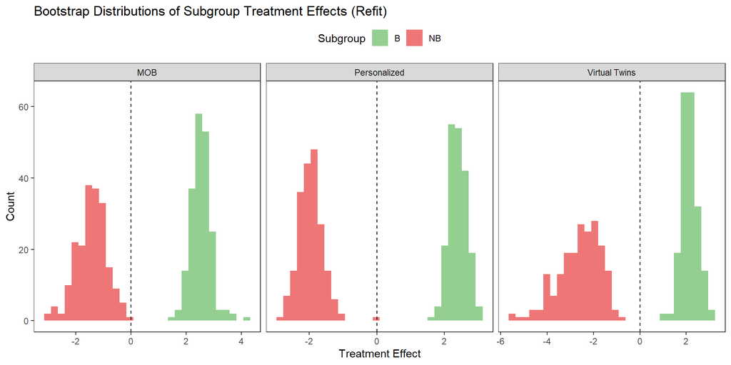

```r
# Visualize bootstrap distributions
boot_dist <- bind_rows(
  data.frame(sg_method = "Virtual Twins", B = boot_vt$t[, 1], NB = boot_vt$t[, 2]),
  data.frame(sg_method = "MOB", B = boot_mob$t[, 1], NB = boot_mob$t[, 2]),
  data.frame(sg_method = "Personalized", B = boot_pers$t[, 1], NB = boot_pers$t[, 2])
) %>%
  pivot_longer(cols = c(B, NB), names_to = "subgroup", values_to = "effect")

ggplot(boot_dist, aes(x = effect, fill = subgroup)) +
  geom_histogram(bins = 30, alpha = 0.6, position = "identity") +
  facet_wrap(~ sg_method, scales = "free_x") +
  scale_fill_manual(values = c("B" = "#4DAF4A", "NB" = "#E41A1C")) +
  geom_vline(xintercept = 0, linetype = "dashed") +
  labs(
    title = "Bootstrap Distributions of Subgroup Treatment Effects (Refit)",
    x = "Treatment Effect", y = "Count", fill = "Subgroup"
  ) +
  theme_bw(base_size = 11) +
  theme(panel.grid = element_blank(), legend.position = "top")
```

## 8.4 Debiased Bootstrap

Guo and He (2021) proposed a resampling-based bias-correction method that adjusts for subgroup selection, but without the need to repeat the entire subgroup identification algorithm. Following Zhao, Ivanova, and Fine (2023), the bootstrap method is as follows:

1. The observed data consist of $n$ independent observations. Each patient $i$ has outcome $Y_i$, treatment $\text{Trt}_i$, and belongs to a candidate subgroup $S_i \in \{B, NB\}$, where the subgroup labels are generated once in the identification phase and then held fixed.
2. Create a nonparametric bootstrap sample by sampling $n$ patients with replacement. The estimated treatment effect in subgroup $s$ in bootstrap sample $b$ is denoted $\hat{\Delta}^*_{s,b}$. Define $\hat{\Delta}_{\max} = \max_s \hat{\Delta}_s$ as the largest observed subgroup treatment effect (i.e., the effect in the identified benefitting subgroup). Given asymptotic normality and bootstrap consistency, the bias between the true effect $\Delta_s$ and the estimated effect $\hat{\Delta}_s$ in subgroup $s$ can be learned through the bias between $\hat{\Delta}_s$ and the bootstrap-adjusted estimate $\hat{\Delta}^*_{s,b} + d_s$, where the adjustment value is:
   $$d_s = (1 - n^{r -
   0.5})(\hat{\Delta}_{\max} - \hat{\Delta}_s)$$
   and $r \in (0, 0.5)$ is a tuning parameter (we use $r = 1/12$).
3. Obtain the debiased estimator by removing from $\hat{\Delta}_{\max}$ the learned bias from bootstrap estimates:
   $$\hat{\Delta}_{\max,\text{debiased}} =
   \hat{\Delta}_{\max} - E^*\left[\max_s(\hat{\Delta}^*_s + d_s) -
   \hat{\Delta}_{\max}\right]$$
   The corresponding two-sided level $1-\alpha$ confidence interval is:
   $$\hat{\Delta}_{\max,\text{debiased}} \pm
   c_{\alpha/2}/\sqrt{n}$$
   where $c_{\alpha/2}$ is the $(1 - \alpha/2)$ quantile of $T^*_b = \sqrt{n}(\max_s(\hat{\Delta}^*_{s,b} + d_s) - \hat{\Delta}_{\max})$.

The same logic applies symmetrically to the NB subgroup by targeting $\Delta_{\min} = \min_s \hat{\Delta}_s$.

```r
# ============================================================
# Debiased Bootstrap (Guo & He, 2021)
# ============================================================
# Key distinction from the refit bootstrap above:
#   - Refit bootstrap: re-identifies subgroups in each resample (captures full uncertainty)
#   - Debiased bootstrap: holds subgroup labels FIXED, only re-estimates effects
#     within fixed labels. This is the "confirmation phase" approach.

# --- Step 1: Fixed-label bootstrap statistic functions ---
# These use the ORIGINAL subgroup labels and only re-estimate treatment effects.

make_fixed_label_boot_stat <- function(fixed_labels) {
  # fixed_labels: character vector of "B"/"NB" per patient (same order as boot_data)
  function(data, indices) {
    d <- data[indices, ]
    sg <- fixed_labels[indices]  # carry the fixed labels along with resampled patients
    Y_b <- d$Y
    Trt_b <- d$Trt

    result <- c(B = NA_real_, NB = NA_real_)
    for (s in c("B", "NB")) {
      idx <- sg == s
      n_trt <- sum(idx & Trt_b == 1)
      n_ctl <- sum(idx & Trt_b == 0)
      if (n_trt > 1 && n_ctl > 1) {
        result[s] <- mean(Y_b[idx & Trt_b == 1]) - mean(Y_b[idx & Trt_b == 0])
      }
    }
    result
  }
}

# Create fixed-label boot statistics for each subgroup method
boot_stat_vt_fixed   <- make_fixed_label_boot_stat(dat$vt_binary)
boot_stat_mob_fixed  <- make_fixed_label_boot_stat(dat$mob_binary)
boot_stat_pers_fixed <- make_fixed_label_boot_stat(dat$pers_subgroup)

# --- Step 2: Run fixed-label bootstrap ---
B_debias <- 2000  # more replicates for debiasing (no CATE refit, so much faster)

set.seed(2026)

cat("Running fixed-label bootstrap for Virtual Twins...\n")
```

```
## Running fixed-label bootstrap for Virtual Twins...
```

```r
boot_vt_fixed <- boot(data = boot_data, statistic = boot_stat_vt_fixed, R = B_debias)

cat("Running fixed-label bootstrap for MOB...\n")
```

```
## Running fixed-label bootstrap for MOB...
```

```r
boot_mob_fixed <- boot(data = boot_data, statistic = boot_stat_mob_fixed, R = B_debias)

cat("Running fixed-label bootstrap for Personalized...\n")
```

```
## Running fixed-label bootstrap for Personalized...
```

```r
boot_pers_fixed <- boot(data = boot_data, statistic = boot_stat_pers_fixed, R = B_debias)

# --- Step 3: Apply debiased bootstrap ---

debiased_subgroup <- function(boot_obj, n, r = 1/12, alpha = 0.05) {
  beta_hat <- boot_obj$t0                          # original point estimates (B, NB)
  k <- length(beta_hat)
  B_boot <- nrow(boot_obj$t)

  # --- Debias the MAX (Benefitting subgroup) ---
  beta_hat_max <- max(beta_hat)
  di <- (1 - n^(r - 0.5)) * (beta_hat_max - beta_hat)  # offsets for max

  Tstar <- numeric(B_boot)
  beta_star_max_mod <- numeric(B_boot)
  valid_max <- rep(TRUE, B_boot)

  for (b in seq_len(B_boot)) {
    beta_star <- boot_obj$t[b, ]
    if (any(is.na(beta_star))) { valid_max[b] <- FALSE; next }
    beta_star_mod <- beta_star + di
    max_mod <- max(beta_star_mod)
    Tstar[b] <- sqrt(n) * (max_mod - beta_hat_max)
    beta_star_max_mod[b] <- max_mod
  }

  Tstar <- Tstar[valid_max]
  beta_star_max_mod <- beta_star_max_mod[valid_max]

  # Debiased estimate
  bias_star <- mean(beta_star_max_mod - beta_hat_max)
  beta_hat_max_debiased <- beta_hat_max - bias_star
  se_max <- sd(beta_star_max_mod)

  # Two-sided CI: debiased ± c_{alpha/2} / sqrt(n)
  c_lower <- quantile(Tstar, alpha / 2)
  c_upper <- quantile(Tstar, 1 - alpha / 2)
  lower_CI_max <- beta_hat_max_debiased - c_upper / sqrt(n)
  upper_CI_max <- beta_hat_max_debiased - c_lower / sqrt(n)

  # --- Debias the MIN (Non-Benefitting subgroup) ---
  beta_hat_min <- min(beta_hat)
  di_min <- (1 - n^(r - 0.5)) * (beta_hat_min - beta_hat)  # offsets for min (≤ 0)

  Tstar_min <- numeric(B_boot)
  beta_star_min_mod <- numeric(B_boot)
  valid_min <- rep(TRUE, B_boot)

  for (b in seq_len(B_boot)) {
    beta_star <- boot_obj$t[b, ]
    if (any(is.na(beta_star))) { valid_min[b] <- FALSE; next }
    beta_star_mod_min <- beta_star + di_min
    min_mod <- min(beta_star_mod_min)
    Tstar_min[b] <- sqrt(n) * (min_mod - beta_hat_min)
    beta_star_min_mod[b] <- min_mod
  }

  Tstar_min <- Tstar_min[valid_min]
  beta_star_min_mod <- beta_star_min_mod[valid_min]

  # Debiased estimate for min
  bias_star_min <- mean(beta_star_min_mod - beta_hat_min)
  beta_hat_min_debiased <- beta_hat_min - bias_star_min
  se_min <- sd(beta_star_min_mod)

  # Two-sided CI for min
  c_lower_min <- quantile(Tstar_min, alpha / 2)
  c_upper_min <- quantile(Tstar_min, 1 - alpha / 2)
  lower_CI_min <- beta_hat_min_debiased - c_upper_min / sqrt(n)
  upper_CI_min <- beta_hat_min_debiased - c_lower_min / sqrt(n)

  list(
    beta_hat_max = beta_hat_max,
    beta_hat_max_debiased = beta_hat_max_debiased,
    lower_CI_max = lower_CI_max,
    upper_CI_max = upper_CI_max,
    se_max = se_max,
    bias_max = bias_star,
    max_subgroup = names(beta_hat)[which.max(beta_hat)],
    beta_hat_min = beta_hat_min,
    beta_hat_min_debiased = beta_hat_min_debiased,
    lower_CI_min = lower_CI_min,
    upper_CI_min = upper_CI_min,
    se_min = se_min,
    bias_min = bias_star_min,
    min_subgroup = names(beta_hat)[which.min(beta_hat)],
    r = r, alpha = alpha, n = n
  )
}

# Apply to each subgroup identification method
db_vt   <- debiased_subgroup(boot_vt_fixed,   n = nrow(boot_data))
db_mob  <- debiased_subgroup(boot_mob_fixed,  n = nrow(boot_data))
db_pers <- debiased_subgroup(boot_pers_fixed, n = nrow(boot_data))

# --- Step 4: Compile results ---
methods_vec <- c("Virtual Twins", "MOB", "Personalized")
db_list <- list(db_vt, db_mob, db_pers)

debiased_results <- bind_rows(
  lapply(seq_along(methods_vec), function(j) {
    db <- db_list[[j]]
    m <- methods_vec[j]

    naive_B  <- naive_results[naive_results$sg_method == m & naive_results$subgroup == "B", ]
    naive_NB <- naive_results[naive_results$sg_method == m & naive_results$subgroup == "NB", ]

    bind_rows(
      data.frame(
        sg_method = m, subgroup = "B",
        n = naive_B$n,
        estimate = db$beta_hat_max_debiased,
        se = db$se_max,
        lower = db$lower_CI_max,
        upper = db$upper_CI_max,
        true_ate = naive_B$true_ate,
        est_method = "Debiased Bootstrap",
        row.names = NULL
      ),
      data.frame(
        sg_method = m, subgroup = "NB",
        n = naive_NB$n,
        estimate = db$beta_hat_min_debiased,
        se = db$se_min,
        lower = db$lower_CI_min,
        upper = db$upper_CI_min,
        true_ate = naive_NB$true_ate,
        est_method = "Debiased Bootstrap",
        row.names = NULL
      )
    )
  })
)

# Print diagnostics (single cat for clean knitted output)
out <- c(
  "Debiased Bootstrap Results (Guo & He 2021)",
  paste0("Fixed subgroup labels | Tuning parameter r = 1/12 | Two-sided 95% CI"),
  paste0("Bootstrap replicates: ", B_debias),
  ""
)
for (j in seq_along(methods_vec)) {
  db <- db_list[[j]]
  out <- c(out,
    paste0(methods_vec[j], ":"),
    paste0("  B:  original = ", round(db$beta_hat_max, 3),
           "  debiased = ", round(db$beta_hat_max_debiased, 3),
           "  bias = ", round(db$bias_max, 3),
           "  95% CI = [", round(db$lower_CI_max, 3), ", ", round(db$upper_CI_max, 3), "]"),
    paste0("  NB: original = ", round(db$beta_hat_min, 3),
           "  debiased = ", round(db$beta_hat_min_debiased, 3),
           "  bias = ", round(db$bias_min, 3),
           "  95% CI = [", round(db$lower_CI_min, 3), ", ", round(db$upper_CI_min, 3), "]"),
    ""
  )
}
cat(paste(out, collapse = "\n"), "\n")
```

```
## Debiased Bootstrap Results (Guo & He 2021)
## Fixed subgroup labels | Tuning parameter r = 1/12 | Two-sided 95% CI
## Bootstrap replicates: 2000
##
## Virtual Twins:
##   B:  original = 1.857  debiased = 1.781  bias = 0.077  95% CI = [1.145, 2.215]
##   NB: original = -3.141  debiased = -3.06  bias = -0.08  95% CI = [-3.661, -2.114]
##
## MOB:
##   B:  original = 2.582  debiased = 2.524  bias = 0.058  95% CI = [1.981, 2.943]
##   NB: original = -1.011  debiased = -0.943  bias = -0.068  95% CI = [-1.375, -0.293]
##
## Personalized:
##   B:  original = 2.289  debiased = 2.235  bias = 0.053  95% CI = [1.707, 2.626]
##   NB: original = -2.012  debiased = -1.967  bias = -0.045  95% CI = [-2.445, -1.236]
##
```

# 9 Comparing All Subgroup-Level Estimation Approaches

## 9.1 Summary Table

```r
# Combine all estimation methods
all_results <- bind_rows(
  naive_results,
  boot_results,
  debiased_results
) %>%
  mutate(
    # Fill bias_corrected as NA for non-bootstrap methods
    bias_corrected = ifelse(is.na(bias_corrected), NA_real_, bias_corrected),
    bias = estimate - true_ate,
    covers = (true_ate >= lower) & (true_ate <= upper),
    ci_width = upper - lower
  )
rownames(all_results) <- NULL

knitr::kable(
  all_results %>%
    select(sg_method, subgroup, est_method, n, estimate, bias_corrected,
           true_ate, bias, se, lower, upper, covers) %>%
    arrange(sg_method, subgroup, est_method),
  digits = 3,
  col.names = c("SG Method", "Subgroup", "Est. Method", "n", "Estimate",
                "Bias-Corrected", "True ATE", "Bias", "SE",
                "Lower", "Upper", "Covers"),
  caption = "Complete Subgroup Treatment Effect Estimates — All Methods"
)
```

Complete Subgroup Treatment Effect Estimates — All Methods

| SG Method | Subgroup | Est. Method | n | Estimate | Bias-Corrected | True ATE | Bias | SE | Lower | Upper | Covers |
| --- | --- | --- | --- | --- | --- | --- | --- | --- | --- | --- | --- |
| MOB | B | Bootstrap (Refit) | 229 | 2.534 | 2.428 | 2.670 | -0.137 | 0.359 | 1.848 | 3.369 | TRUE |
| MOB | B | Debiased Bootstrap | 229 | 2.524 | NA | 2.670 | -0.146 | 0.241 | 1.981 | 2.943 | TRUE |
| MOB | B | Naive | 229 | 2.582 | NA | 2.670 | -0.088 | 0.272 | 2.046 | 3.119 | TRUE |
| MOB | NB | Bootstrap (Refit) | 171 | -1.430 | -0.976 | -1.247 | -0.182 | 0.552 | -2.795 | -0.319 | TRUE |
| MOB | NB | Debiased Bootstrap | 171 | -0.943 | NA | -1.247 | 0.305 | 0.278 | -1.375 | -0.293 | TRUE |
| MOB | NB | Naive | 171 | -1.011 | NA | -1.247 | 0.237 | 0.327 | -1.657 | -0.365 | TRUE |
| Personalized | B | Bootstrap (Refit) | 281 | 2.393 | 2.034 | 2.321 | 0.072 | 0.258 | 1.900 | 2.914 | TRUE |
| Personalized | B | Debiased Bootstrap | 281 | 2.235 | NA | 2.321 | -0.086 | 0.238 | 1.707 | 2.626 | TRUE |
| Personalized | B | Naive | 281 | 2.289 | NA | 2.321 | -0.033 | 0.256 | 1.785 | 2.792 | TRUE |
| Personalized | NB | Bootstrap (Refit) | 119 | -1.958 | -2.338 | -2.135 | 0.177 | 0.362 | -2.648 | -1.240 | TRUE |
| Personalized | NB | Debiased Bootstrap | 119 | -1.967 | NA | -2.135 | 0.169 | 0.312 | -2.445 | -1.236 | TRUE |
| Personalized | NB | Naive | 119 | -2.012 | NA | -2.135 | 0.124 | 0.355 | -2.715 | -1.309 | TRUE |
| Virtual Twins | B | Bootstrap (Refit) | 335 | 2.135 | 1.580 | 1.746 | 0.389 | 0.349 | 1.484 | 2.907 | TRUE |
| Virtual Twins | B | Debiased Bootstrap | 335 | 1.781 | NA | 1.746 | 0.035 | 0.271 | 1.145 | 2.215 | TRUE |
| Virtual Twins | B | Naive | 335 | 1.857 | NA | 1.746 | 0.111 | 0.263 | 1.341 | 2.374 | TRUE |
| Virtual Twins | NB | Bootstrap (Refit) | 65 | -2.616 | -3.665 | -2.874 | 0.258 | 0.912 | -4.628 | -1.285 | TRUE |
| Virtual Twins | NB | Debiased Bootstrap | 65 | -3.060 | NA | -2.874 | -0.186 | 0.398 | -3.661 | -2.114 | TRUE |
| Virtual Twins | NB | Naive | 65 | -3.141 | NA | -2.874 | -0.267 | 0.475 | -4.089 | -2.192 | TRUE |

## 9.2 Forest Plot

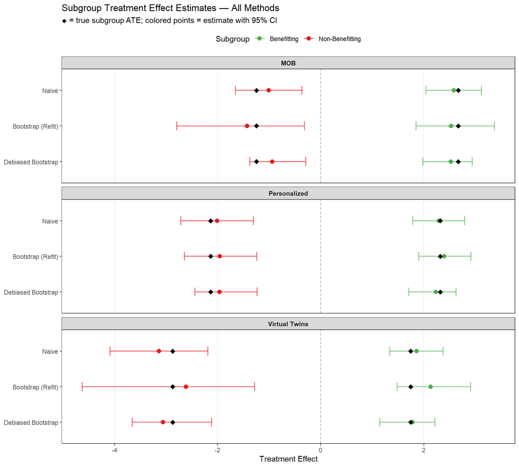

```r
# Forest plot: all subgroup methods × estimation methods
# Color by Benefitting / Non-Benefitting subgroup
# y-axis shows clean method labels grouped by subgroup
all_results <- all_results %>%
  mutate(
    subgroup_label = ifelse(subgroup == "B", "Benefitting", "Non-Benefitting"),
    y_label = paste0(est_method)
  )

# Order: within each facet, group by subgroup (B then NB), then method
method_order <- c("Naive", "Bootstrap (Refit)", "Debiased Bootstrap")
all_results <- all_results %>%
  mutate(y_label = factor(y_label, levels = rev(method_order)))

ggplot(all_results, aes(y = y_label, x = estimate, color = subgroup_label)) +
  geom_point(size = 2.5) +
  geom_errorbarh(aes(xmin = lower, xmax = upper), height = 0.25) +
  geom_point(aes(x = true_ate), shape = 18, size = 3, color = "black") +
  geom_vline(xintercept = 0, linetype = "dashed", color = "grey60") +
  facet_wrap(~ sg_method, ncol = 1, scales = "free_y") +
  scale_color_manual(values = c("Benefitting" = "#4DAF4A", "Non-Benefitting" = "#E41A1C")) +
  labs(
    title = "Subgroup Treatment Effect Estimates — All Methods",
    subtitle = "◆ = true subgroup ATE; colored points = estimate with 95% CI",
    x = "Treatment Effect", y = NULL,
    color = "Subgroup"
  ) +
  theme_bw(base_size = 11) +
  theme(
    panel.grid.major.y = element_blank(),
    panel.grid.minor = element_blank(),
    legend.position = "top",
    strip.text = element_text(face = "bold")
  )
```

## 9.3 Virtual Twins Forest Plot

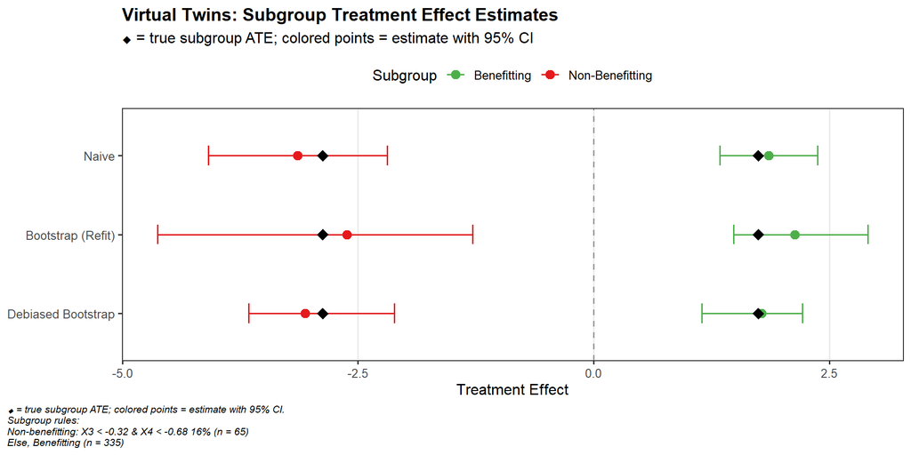

```r
# Filter to Virtual Twins only
vt_results <- all_results %>%
  filter(sg_method == "Virtual Twins")

# Build dynamic caption with subgroup rules from the VT tree
# Show NB rule explicitly, collapse all B leaves into one line
vt_rules_text <- tryCatch({
  rules <- rpart.rules(vt_tree, style = "tall", cover = TRUE)
  leaf_ids <- rownames(rules)

  nb_lines <- character()
  n_b_total <- 0

  for (i in seq_len(nrow(rules))) {
    leaf_id_char <- as.character(which(rownames(vt_tree$frame) == leaf_ids[i]))
    label <- vt_leaf_class[leaf_id_char]
    n_leaf <- sum(vt_leaf == leaf_id_char)
    rule_text <- paste(trimws(rules[i, ]), collapse = " ")
    rule_text <- gsub(" when ", " ", rule_text)
    # Strip the leading predicted CATE value (e.g. "-1.5072 X3..." -> "X3...")
    rule_text <- sub("^-?[0-9]+\\.?[0-9]*\\s+", "", rule_text)

    if (label == "NB") {
      nb_lines <- c(nb_lines, paste0("Non-benefitting: ", rule_text, " (n = ", n_leaf, ")"))
    } else {
      n_b_total <- n_b_total + n_leaf
    }
  }

  b_line <- paste0("Else, Benefitting (n = ", n_b_total, ")")
  paste(c(nb_lines, b_line), collapse = "\n")
}, error = function(e) {
  "Subgroups defined by Virtual Twins regression tree on X-Learner CATEs."
})

caption_text <- paste0(
  "\u25C6 = true subgroup ATE; colored points = estimate with 95% CI.\n",
  "Subgroup rules:\n", vt_rules_text
)

method_order <- c("Naive", "Bootstrap (Refit)", "Debiased Bootstrap")
vt_results <- vt_results %>%
  mutate(y_label = factor(est_method, levels = rev(method_order)))

p_vt_forest <- ggplot(vt_results, aes(y = y_label, x = estimate, color = subgroup_label)) +
  geom_point(size = 3) +
  geom_errorbarh(aes(xmin = lower, xmax = upper), height = 0.25) +
  geom_point(aes(x = true_ate), shape = 18, size = 4, color = "black") +
  geom_vline(xintercept = 0, linetype = "dashed", color = "grey60") +
  scale_color_manual(values = c("Benefitting" = "#4DAF4A", "Non-Benefitting" = "#E41A1C")) +
  labs(
    title = "Virtual Twins: Subgroup Treatment Effect Estimates",
    subtitle = expression(paste(
      "\u25C6 = true subgroup ATE; colored points = estimate with 95% CI"
    )),
    x = "Treatment Effect", y = NULL,
    color = "Subgroup",
    caption = caption_text
  ) +
  theme_bw(base_size = 12) +
  theme(
    panel.grid.major.y = element_blank(),
    panel.grid.minor = element_blank(),
    legend.position = "top",
    plot.title = element_text(size = 14, face = "bold"),
    plot.caption = element_text(size = 8, hjust = 0, face = "italic"),
    plot.caption.position = "plot"
  )

p_vt_forest
```

# References

Chen, Shuai, Lu Tian, Tianxi Cai, and Menggang Yu. 2017. “A General Statistical Framework for Subgroup Identification and Comparative Treatment Scoring.” *Biometrics* 73 (4): 1199–209. https://doi.org/10.1111/biom.12676.

Foster, Jared C, Jeremy MG Taylor, and Stephen J Ruberg. 2011. “Subgroup Identification from Randomized Clinical Trial Data.” *Statistics in Medicine* 30 (24): 2867–80. https://doi.org/10.1002/sim.4322.

Guo, Xinzhou, and Xuming He. 2021. “Inference on Selected Subgroups in Clinical Trials.” *Journal of the American Statistical Association* 116: 1498–1506.

Huling, Jared D, and Menggang Yu. 2024. *Personalized: Estimation and Validation Methods for Subgroup Identification and Personalized Medicine*. https://CRAN.R-project.org/package=personalized.

Zeileis, Achim, Torsten Hothorn, and Kurt Hornik. 2008. “Model-Based Recursive Partitioning.” *Journal of Computational and Graphical Statistics* 17 (2): 492–514. https://doi.org/10.1198/106186008X319331.

Zhao, Bo, Anastasia Ivanova, and Jason Fine. 2023. “Inference on Subgroups Identified Based on Heterogeneous Treatment Effect in a Post Hoc Analysis of a Clinical Trial.” *Clinical Trials* 20 (4): 370–79.